# Currency Notes

Currency Notes

Pakistan

5000

[figure not shown]

[figure not shown]

1000

[figure not shown]

500

[figure not shown]

100

[figure not shown]

50

[figure not shown]

20

[figure not shown]

10

[figure not shown]

5

[figure not shown]

2

[figure not shown]

1

[figure not shown]

[figure not shown]

50 paisa

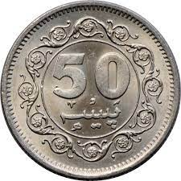

[figure not shown]

25 paisa

[figure not shown]

10 paisa

[figure not shown]

5 paisa

[figure not shown]

2 paisa

[figure not shown]

USA

500

[figure not shown]

100

[figure not shown]

[figure not shown]

[figure not shown]

50

[figure not shown]

20

[figure not shown]

10

[figure not shown]

5

[figure not shown]

1

[figure not shown]

2

[figure not shown]

Quarter dollar

[figure not shown]

[figure not shown]

Dime

[figure not shown]

Nickel

[figure not shown]

Cent

[figure not shown]

[figure not shown]

[figure not shown]

Saudi Arabia

500

[figure not shown]

king Abdul Aziz photo.

[figure not shown]

[figure not shown]

100

[figure not shown]

[figure not shown]

[figure not shown]

[figure not shown]

[figure not shown]

[figure not shown]

20

[figure not shown]

10

[figure not shown]

[figure not shown]

5

[figure not shown]

[figure not shown]

[figure not shown]

[figure not shown]

[figure not shown]

[figure not shown]

[figure not shown]

[figure not shown]

[figure not shown]

[figure not shown]

UAE

1000

[figure not shown]

[figure not shown]

500

[figure not shown]

[figure not shown]

100

[figure not shown]

[figure not shown]

50

[figure not shown]

20 aed

[figure not shown]

[figure not shown]

10

[figure not shown]

5

[figure not shown]

[figure not shown]

1

[figure not shown]

[figure not shown]

[figure not shown]

UK

100

[figure not shown]

[figure not shown]

**Europe – Euro (€) (used in France, Germany, Italy, Spain, Netherlands and other Eurozone countries)**

500

[figure not shown]

200

[figure not shown]

100

[figure not shown]

50

[figure not shown]

20

[figure not shown]

10

[figure not shown]

5

[figure not shown]

**Australia – Australian Dollar (AUD)**

100

[figure not shown]

50

[figure not shown]

20

[figure not shown]

10

[figure not shown]

5

[figure not shown]

2 dollar coin

[figure not shown]

1 dollar coin

[figure not shown]

**Canada – Canadian Dollar (CAD)**

100, 50, 20, 10, 5 (Frontier series)

[figure not shown]

20 (commemorative)

[figure not shown]

Loonie (1 dollar) and Toonie (2 dollar) coins

[figure not shown]

**Japan – Japanese Yen (JPY)**

10000

[figure not shown]

5000

[figure not shown]

2000

[figure not shown]

1000

[figure not shown]

**India – Indian Rupee (INR)**

500

[figure not shown]

200

[figure not shown]

100

[figure not shown]

50

[figure not shown]

20

[figure not shown]

10

[figure not shown]

**Turkey – Turkish Lira (TRY)**

200

[figure not shown]

100

[figure not shown]

50

[figure not shown]

20

[figure not shown]

10

[figure not shown]

5

[figure not shown]

Euro, Australian, Canadian, Japanese, Indian and Turkish note images: Wikimedia Commons / Wikipedia.